```python
import numpy as np, pandas as pd, scipy.stats, sympy, matplotlib.pyplot as plt,matplotlib as mpl, math
from numpy import random_intel
from matplotlib import rc
rc('text', usetex=True)
mpl.rcParams['figure.dpi'] = 150
mpl.rcParams['savefig.dpi'] = 300
```

# Exercise 2

In the excercise you can use a build in procedure for generating uniform random variables. Compare the results obtained in simulations with expected results. Use histograms (and tests).

- Choice a value for p in the geometric distribution and simulate 10,000 outcomes.
- Simulate the 6 point distribution with

X: 1, 2, 3, 4, 5, 6

p_i: 7/48, 5/48, 1/8, 1/16, 1/4, 5/16

– by applying a direct (crude) method – by using the the rejction method – by using the Alias method

Intializing the random generation with built in generator. In this case numpy (np) used the Marissene Twister. Seed has been chosen such that results can be reconstructed. \begin{equation} U \sim U(0,1) \end{equation}

```python
np.random_intel.seed(123)
U = np.random_intel.rand(10000)
print("First five random numbers are reported\n",U[:5])
```

```
First five random numbers are reported
 [0.0523636  0.26767717 0.08718668 0.76895639 0.40724176]
```

## Geometric distribution

```python
n = 6
p = 0.5
X = (np.log(np.array(U))/np.log(1-p))+1
```

## Crude Method

The crude method is implemented using bins where "crudely" each randomly generated number is assigned to the bin corresponding the probablitiy interval.

```python
def crude(U,p_i):
    out = []
    cumP = np.cumsum(p_i)
    for i in U:
        for k,j in enumerate(cumP):
            if i<=j:
                out.append(k+1)
                break
    return out
## Alternativly use:
# np.digitize(U,p_i.cumsum())+1
```

## Rejection Method

The rejection method adds a layer of coltrol to the random generation. Initially the rejection method places a randomly generated number into a bin by similar method as Crude, yet here the bins are uniformly distributed. Afterwards the Acceptance/rejection criteria is checked by testing the next (or previous) againts the probability of $\frac{p_i(I)}{c}$. This method uses more computing time and as some of the results are rejected it is not ensured to produce the same amount og numbers as the unfrom distribution inputted.

```python
def reject(U,p_i):
    out = []
    eps=1e-10
    c=max(p_i)+eps
    for i,j in enumerate(U):
        I = int(np.floor((n*j)))
        U_2 = U[i-1]
        if U_2 < p_i[I]/c:
            out.append(I + 1)
    return out
```

## Alias Method

Much in the same way that the Rejection method works yet now if a random number is rejected then it is "Aliased" to a other bin, that is found by the $L$ list. This method requires more computation time but all the randomly gerenated numbers are used.

```python
def alias(U,p_i,eps=1e-10):

    L = list(range(1,n+1))
    F = n*p_i
    G = np.where(F>=1)[0]
    S = np.where(F<=1)[0]
    while len(S)!=0:
        k = G[0]
        j = S[0]
        L[j] = k
        F[k] -= 1-F[j]
        if F[k] < 1-eps:
            G = np.delete(G,0)
            S = np.append(S,k)
        S = np.delete(S,0)

    out = []

    for i,j in enumerate(U):
        I = int(np.floor((n*j)))
        U_2 = U[i-1]
        if U_2 < F[I]:
            out.append(I+1)
        else:
            out.append(L[I]+1)

    return out
```

# Testing

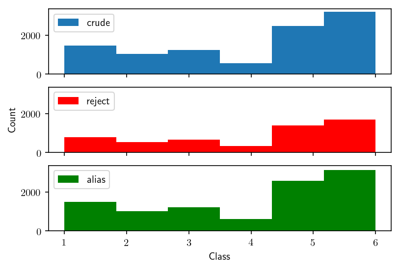

```python
p_i = np.array([7/48, 5/48, 1/8, 1/16, 1/4, 5/16])
first = crude(U,p_i)
second = reject(U,p_i)
third = alias(U,p_i)

fig,axarr=plt.subplots(3,1,sharex='col',sharey='col')
axarr[0].hist(first,6,label= "crude")
axarr[0].legend()
axarr[1].hist(second,6,color="r",label= "reject")
axarr[1].set_ylabel("Count")
axarr[1].legend(loc=2)
axarr[2].hist(third,6,color="g",label= "alias")
plt.xlabel("Class")
axarr[2].legend()
plt.show()
```

Regarding the plots abouve it is very apparent that the rejection method has fewer instances in all classes compared to the alias method. This was also indicated from the theory of the book and further more intition of the two methods. Furtheremore the crude and alias method seem to have very similar preformance and the differenceses will be furthere investigated. It is ixpected that the rejction method will be the worst prefroming method where alias is the best.

```python
bins1 = np.zeros(n)
bins2 = np.zeros(n)
bins3 = np.zeros(n)

for i in first:
    bins1[i-1] += 1

for i in second:
    bins2[i-1] += 1

for i in third:
    bins3[i-1] += 1
```

```python
theoretical = p_i*10000

T1 = sum((bins1-theoretical)**2/theoretical)
T2 = sum((bins2-theoretical)**2/theoretical)
T3 = sum((bins3-theoretical)**2/theoretical)

print("95% conf {:0.8f}, 5% conf {:0.8f}".format(scipy.stats.chi2.ppf(0.95,df=n-1),scipy.stats.chi2.ppf(0.05,df=n-1)))
print("Crude:     {:9.4f}".format(T1))
print("Rejection: {:9.4f}".format(T2))
print("Alias:     {:9.4f}".format(T3))
```

```
95% conf 11.07049769, 5% conf 1.14547623
Crude:        6.0248
Rejection: 2112.9799
Alias:        4.1652
```

Now regarding the results shown above it aligns with expectations shown in the histrgrams previously. It is seen that the rejection method is by far the worlst prfroming generator, mostly caused by rejection of unqualified generations and thereby disregarding it. It it then seen that the crude and alias method preform similarly yet the alias method is slightly better. Both the Crude and Alias method lie within the confidence interval whereas the rejection method does not.

```python
%timeit first = crude(U,p_i)
%timeit second = reject(U,p_i)
%timeit third = alias(U,p_i)
```

```
10.5 ms ± 56.8 µs per loop (mean ± std. dev. of 7 runs, 100 loops each)
30.7 ms ± 130 µs per loop (mean ± std. dev. of 7 runs, 10 loops each)
30.9 ms ± 250 µs per loop (mean ± std. dev. of 7 runs, 10 loops each)
```